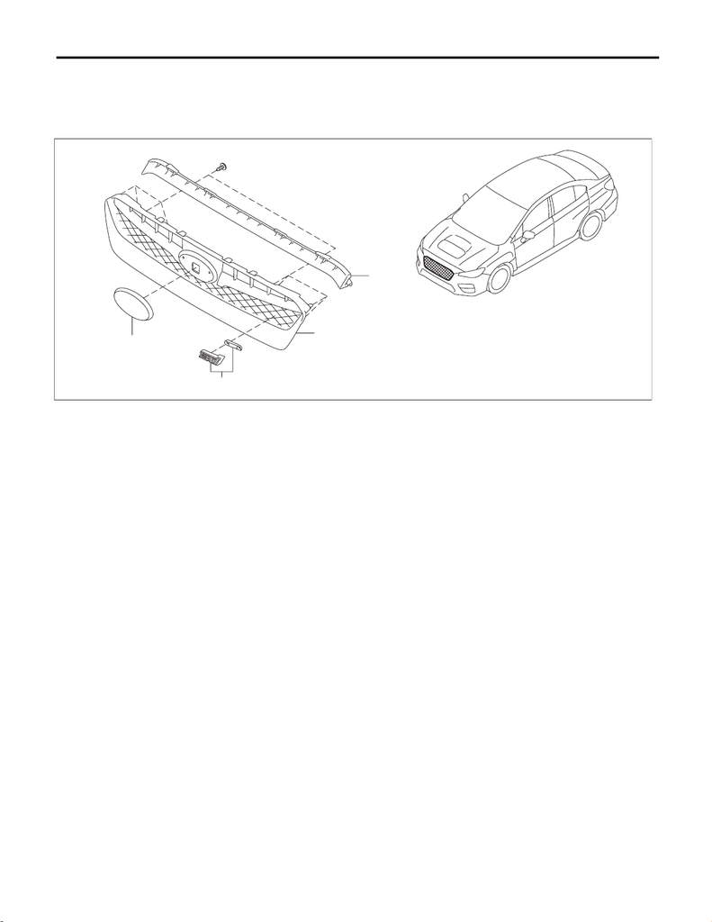

EI-2

General Description

EXTERIOR/INTERIOR TRIM

1. General Description

A: COMPONENT

1. FRONT GRILLE

(1) Front grille emblem (3) Front grille ASSY (4) Spacer grille - front

(2) Ornament

EI-04372

(1)

(2)

(3)

(4)

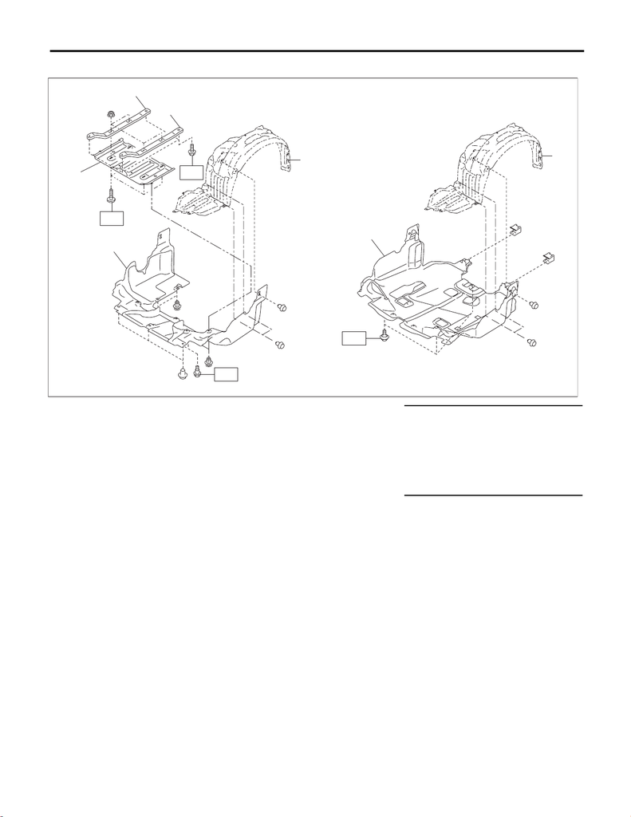

EI-3

General Description

EXTERIOR/INTERIOR TRIM

2. FRONT UNDER COVER

(1) Under cover - front (except for STI

model)

(4) Plate - CTR LH (except for STI

model)

Tightening torque: N·m (kgf-m, ft-lb)

(2) Frame - under cover (except for

STI model)

(5) Mud guard - front T1: 18 (1.8, 13.3)

(3) Plate - CTR RH (except for STI

model)

(6) Under cover - front (STI model) T2: 20 (2.0, 14.8)

T3: 25 (2.5, 18.4)

EI-04345

(6)

(5)

(1)

(3)

(2)

(4)

(5)

T3

T2

T1

T1

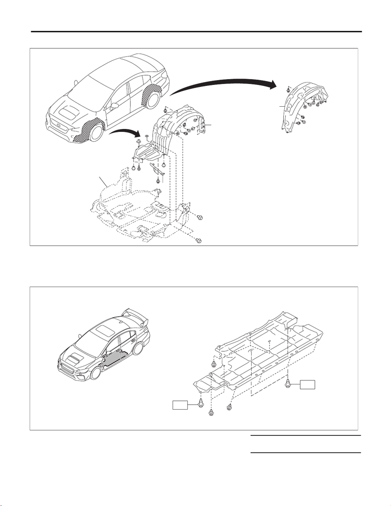

EI-4

General Description

EXTERIOR/INTERIOR TRIM

3. MUD GUARD

4. FLOOR UNDER PROTECTOR

(1) Under cover - front (3) Mud guard - front (4) Mud guard - rear

(2) Cover - fender LWR

Tightening torque: N·m (kgf-m, ft-lb)

T: 7.5 (0.8, 5.5)

EI-04342

(1)

(2)

(4)

(3)

EI-04309

T

T

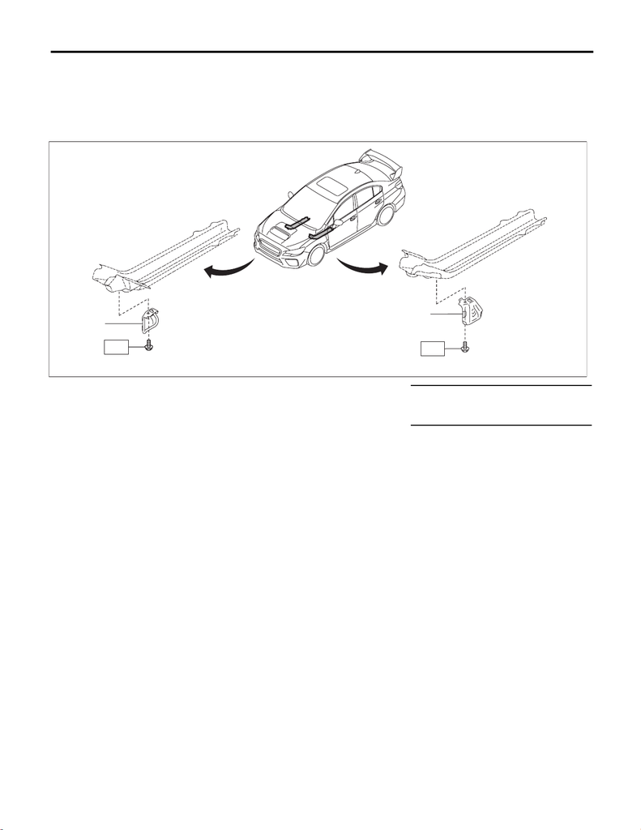

EI-5

General Description

EXTERIOR/INTERIOR TRIM

5. FUEL TANK PROTECTOR

For exploded view of the fuel tank protector, refer to “FUEL TANK” of “FUEL INJECTION” section.

• STI model: <Ref. to FU(STI)-66, REMOVAL, Fuel Tank Protector.>

• Except for STI model: <Ref. to FU(w/o STI)-151, REMOVAL, Fuel Tank Protector.>

6. PROTECTOR OIL COVER

7. FRONT HOOD GRILLE

For exploded view of the front hood grille, refer to “Diesel engine model” in “FRONT HOOD” of “EXTERIOR

BODY PANELS” section. <Ref. to EB-2, FRONT HOOD, COMPONENT, General Description.>

(1) Protector oil cover RH (CVT

model)

(2) Protector oil cover LH (CVT

model)

Tightening torque: N·m (kgf-m, ft-lb)

T: 100 (10.2, 73.8)

EI-04306

(1)

TT

T

(2)

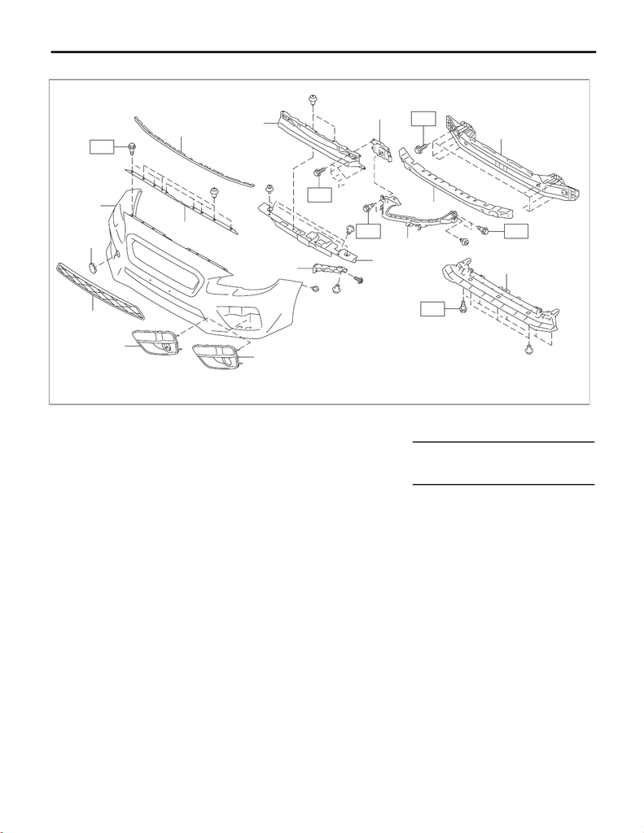

EI-6

General Description

EXTERIOR/INTERIOR TRIM

8. FRONT BUMPER

(1) Sealing bumper - front (8) Bracket - front bumper side (15) Bracket center lower - front

(2) Plate UPR - front (9) Cover UPR - front

(3) Bumper face - front (10) Energy absorber plate - front Tightening torque: N·m (kgf-m, ft-lb)

(4) Cover hook - front (11) Bracket UPR - COMPL T1: 7.5 (0.8, 5.5)

(5) Cover intake - front (12) Bracket - front bumper corner T2: 32 (3.3, 23.6)

(6) Cover - fog light (model without

fog light)

(13) Energy absorber foam

(7) Cover - fog light (model with fog

light)

(14) Bumper beam COMPL - front

EI-04370

T1

T2

T2

(1)

(2)

(3)

(5)

(6)

(7)

(8)

(9)

(10)

(12)

(15)

(14)

(13)

(11)

(4)

T1

T1

T1

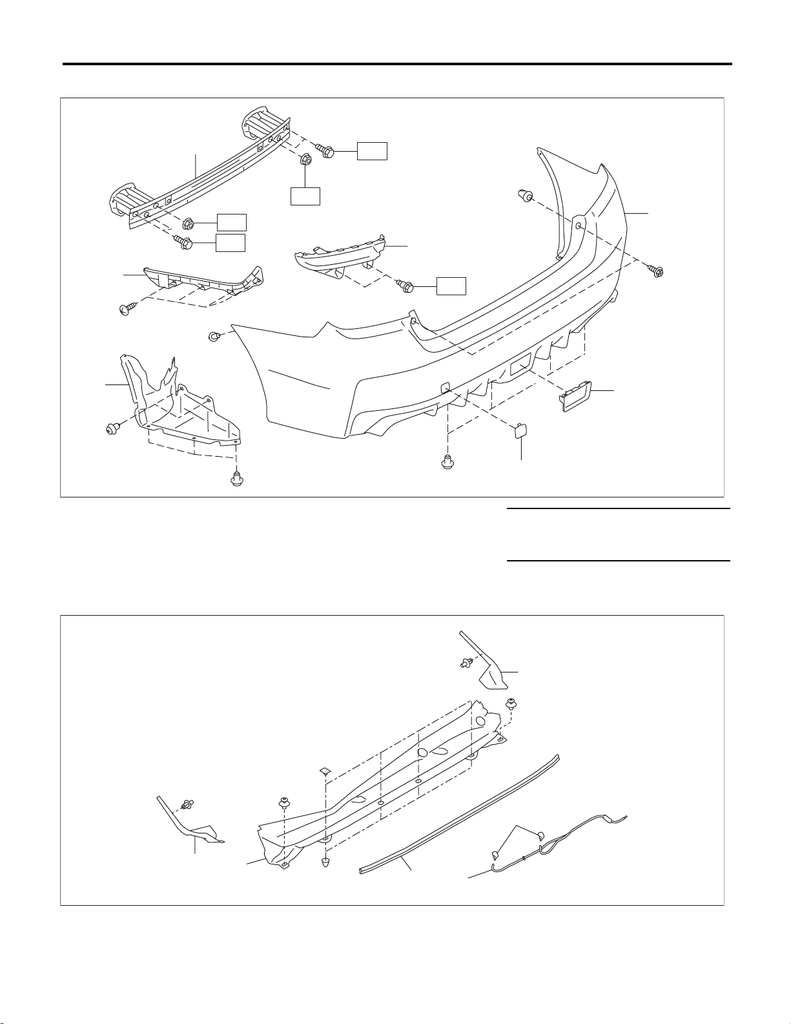

EI-7

General Description

EXTERIOR/INTERIOR TRIM

9. REAR BUMPER

10.COWL PANEL

(1) Bumper beam COMPL - rear (5) Cover - rear bumper A Tightening torque: N·m (kgf-m, ft-lb)

(2) Bracket - rear bumper side (6) Cover - rear bumper B T1: 7.5 (0.8, 5.5)

(3) Bracket - rear bumper corner (7) Bumper face - rear T2: 70 (7.1, 51.6)

(4) Cover - rear bumper side

(1) Cowl panel - side RH (3) Seal - cowl panel (5) Nozzle - windshield washer

(2) Cowl panel ASSY (4) Hose - windshield washer (6) Cowl panel - side LH

EI-04384

(1)

(7)

T1

(2)

(3)

(4)

(5)

(6)

T2

T2

T2

T2

EI-04206

(3)

(1)

(2)

(4)

(5)

(6)

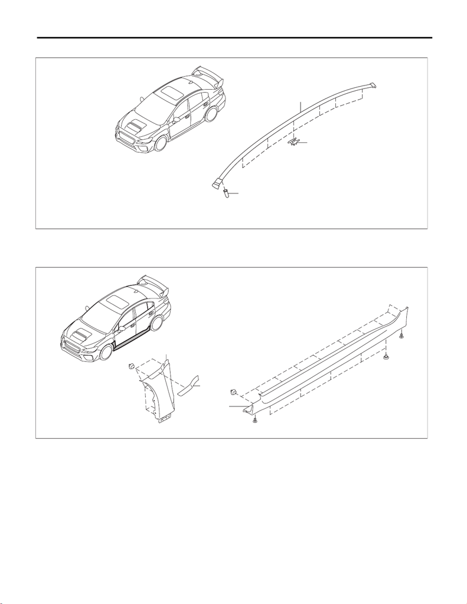

EI-8

General Description

EXTERIOR/INTERIOR TRIM

11.ROOF MOLDING

12.SIDE GARNISH

(1) Rivet (2) Molding - roof (3) Fastener

(1) Garnish ASSY - fender (2) Molding (3) Spoiler ASSY - side

EI-04333

(3)

(1)

(2)

EI-04352

(1)

(2)

(3)

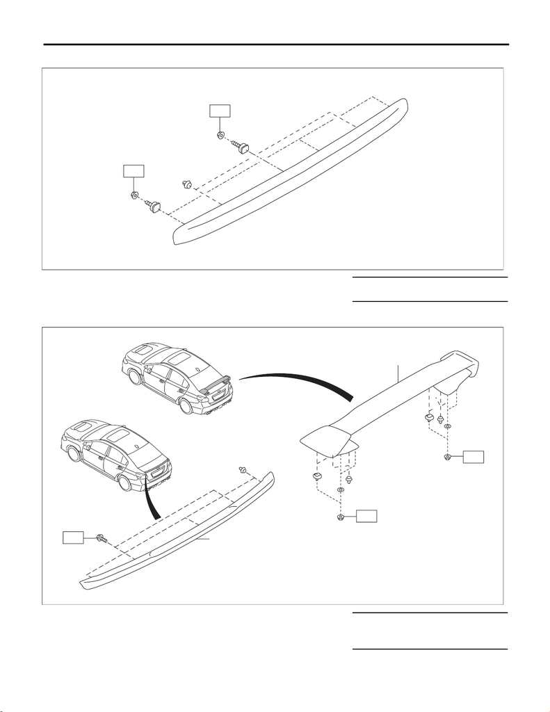

EI-9

General Description

EXTERIOR/INTERIOR TRIM

13.TRUNK LID GARNISH

14.REAR SPOILER

Tightening torque: N·m (kgf-m, ft-lb)

T: 4.5 (0.5, 3.3)

(1) Rear spoiler (small type) (2) Rear spoiler (large type) Tightening torque: N·m (kgf-m, ft-lb)

T1: 4.5 (0.5, 3.3)

T2: 7.5 (0.8, 5.5)

EI-03400

T

T

EI-04335

(1)

(2)

T2

T2

T1

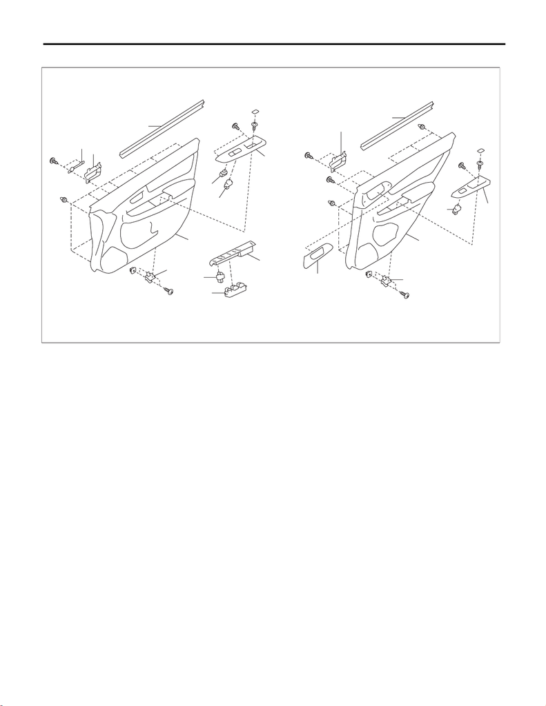

EI-10

General Description

EXTERIOR/INTERIOR TRIM

15.DOOR TRIM

(1) Plate (7) Trim panel - front door (13) Weather strip - door rear INN

(2) Remote ASSY - door (8) Bracket - door trim front (14) Panel - power window sub-switch

rear

(3) Weather strip - door front INN (9) Switch - door mirror (15) Switch - power window sub rear

(4) Panel - power window sub-switch

front

(10) Switch - power window main (16) Trim panel - rear door

(5) Switch - door lock sub (11) Panel - power window main switch (17) Bracket - door trim rear

(6) Switch - power window sub front (12) Cover - remote rear door

EI-04242

(2)

(3)

(4)

(14)

(5)

(6)

(10)

(8)

(7)

(9)

(12)

(15)

(13)

(16)

(11)

(2)

(17)

(1)

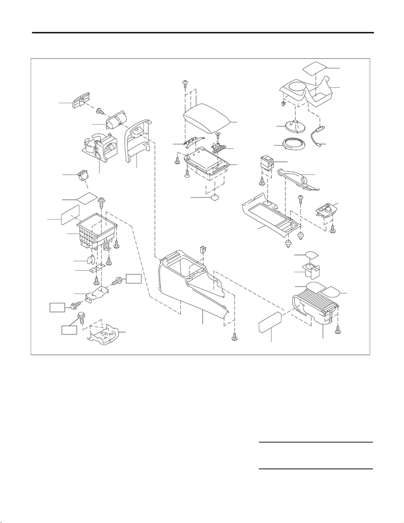

EI-11

General Description

EXTERIOR/INTERIOR TRIM

16.CONSOLE BOX

• STI model

(1) End cap - console box (13) Console box outer (25) Switch - seat heater

(2) Cap - console box (14) Pad - console (26) Boot - parking brake

(3) End cover - console box (15) Cup holder ASSY (27) Switch - SI-DRIVE

(4) Rear - cup holder (16) Mat - cup holder ASSY (28) Antenna - interior front

(5) AUX input terminal (17) Case - cup holder ASSY (29) Ring cover - front

(6) Mat - console pocket (18) Mat - cup holder ASSY (30) Boot - shift lever

(7) Cushion - console (19) Console cover (31) Cover front

(8) Pocket - console (20) Cushion lid lower (32) Mat

(9) Clamp (21) Hinge - COMPL

(10) Bracket - console A (22) Lid - COMPL Tightening torque: N·m (kgf-m, ft-lb)

(12) Bracket - console box (24) Lid lower T2: 18 (1.8, 13.3)

EI-04455

(1)

(2)

(4)

(5)

(6)

(7)

(8)

(9)

(10)

(11)

(12)

(13)

(14)

(15)

(16)

(16)

(18)

(17)

(20)

(24)

(23)

(21)

(22)

(25)

(19)

(26)

(27)

(3)

T1

T2

T1

(32)

(31)

(30)

(28)

(29)

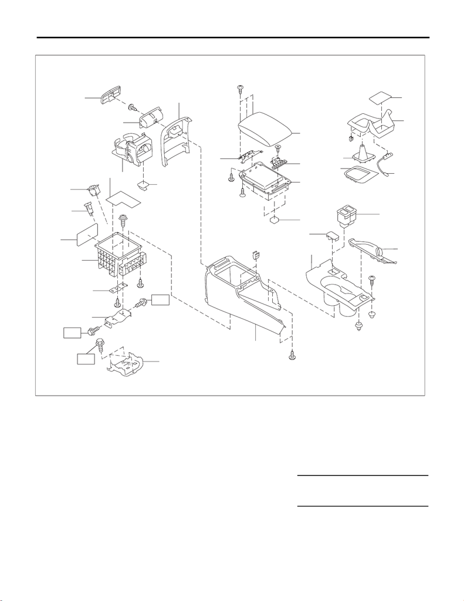

EI-12

General Description

EXTERIOR/INTERIOR TRIM

• Except for STI model

(1) End cap - console box (12) Bracket - console B (23) Lid - COMPL

(2) Cap - console box (13) Bracket - console box (24) Antenna - interior front

(3) End cover - console box (14) Console box outer (25) Ring cover - front

(4) Clamp (15) Boot - parking brake (26) Boot - shift lever

(5) Rear - cup holder (16) Console cover (27) Cover front

(6) Mat - console pocket (17) Cap (28) Mat

(7) AUX input terminal (18) Switch - seat heater

(8) Accessory power supply socket (19) Cushion lid lower Tightening torque: N·m (kgf-m, ft-lb)

(9) Cushion - console (20) Lid lower T1: 6.5 (0.7, 4.8)

(10) Pocket - console (21) Lock - console T2: 18 (1.8, 13.3)

(11) Bracket - console A (22) Hinge - COMPL

EI-04456

(1)

(2)

(3)

(5)

(7)

(8)

(9)

(10)

(11)

(12)

(13)

(14)

(16)

(15)

(17)

(18)

(19)

(20)

(22)

(23)

(21)

(4)

T1

T2

T1

(6)

(28)

(27)

(26)

(24)

(25)

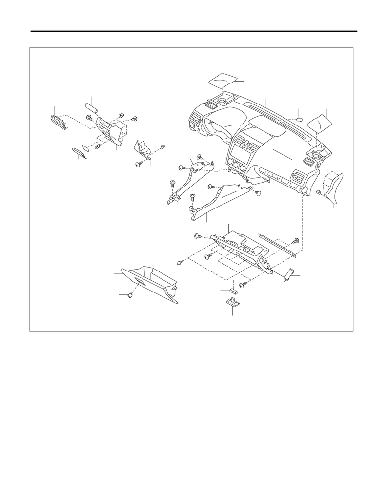

EI-13

General Description

EXTERIOR/INTERIOR TRIM

17.INSTRUMENT PANEL

(1) Panel - switch (7) Panel center LWR RH (13) Damper COMPL - pocket

(2) Ornament - panel ASSY driver (8) Pocket ASSY (14) Cover - instrument panel side RH

(3) Lid ASSY - fuse box (9) Key cylinder - pocket (15) Grille speaker side RH

(4) Cover ASSY - instrument panel

LWR driver OUT

(10) Back panel - pocket (16) Cap - guide pin

(5) Cover ASSY - instrument panel

LWR driver INN

(11) Light - pocket (17) Panel COMPL - instrument

(6) Panel center LWR LH (12) Holder (18) Grille speaker side LH

EI-04327

(4)

(1)

(3)

(2)

(5)

(8)

(7)

(6)

(9)

(15)

(10)

(13)

(12)

(11)

(14)

(16)

(18)

(17)

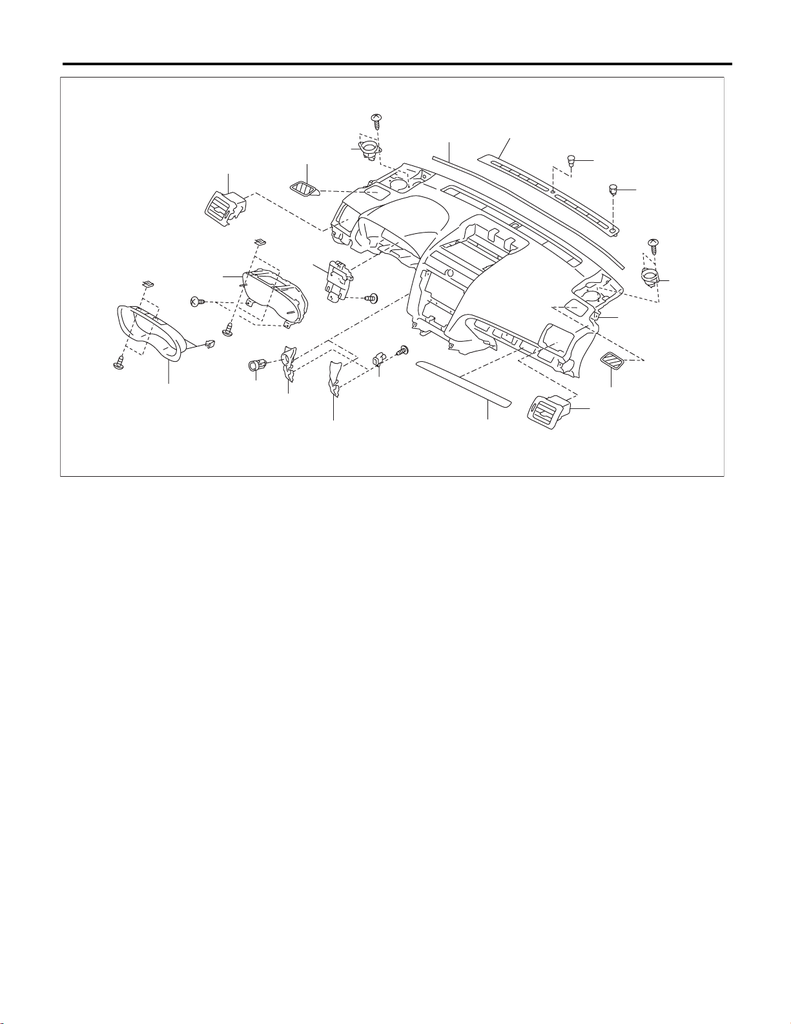

EI-14

General Description

EXTERIOR/INTERIOR TRIM

(1) Speaker ASSY - tweeter LH (8) Panel - switch (15) Speaker ASSY - tweeter RH

(2) Grille defroster - front LH (9) Cover - switch starter (16) Sensor - rain

(3) Grille ASSY - ventilation LH (10) Case - sensor (17) Sensor - sunload

(4) Combination meter ASSY (11) Ornament - panel ASSY passen-

ger

(18) Grille front defroster

(5) Reinforcement - combination

meter

(12) Grille ASSY - ventilation RH (19) Cushion

(6) Visor - combination meter (13) Grille defroster - front RH

(7) Switch - push button start (14) Panel COMPL - instrument

EI-04343

(17)

(1)

(2)

(3)

(4)

(5)

(6)

(11)

(12)

(13)

(14)

(15)

(16)

(18)

(19)

(7)

(8)

(9)

(10)

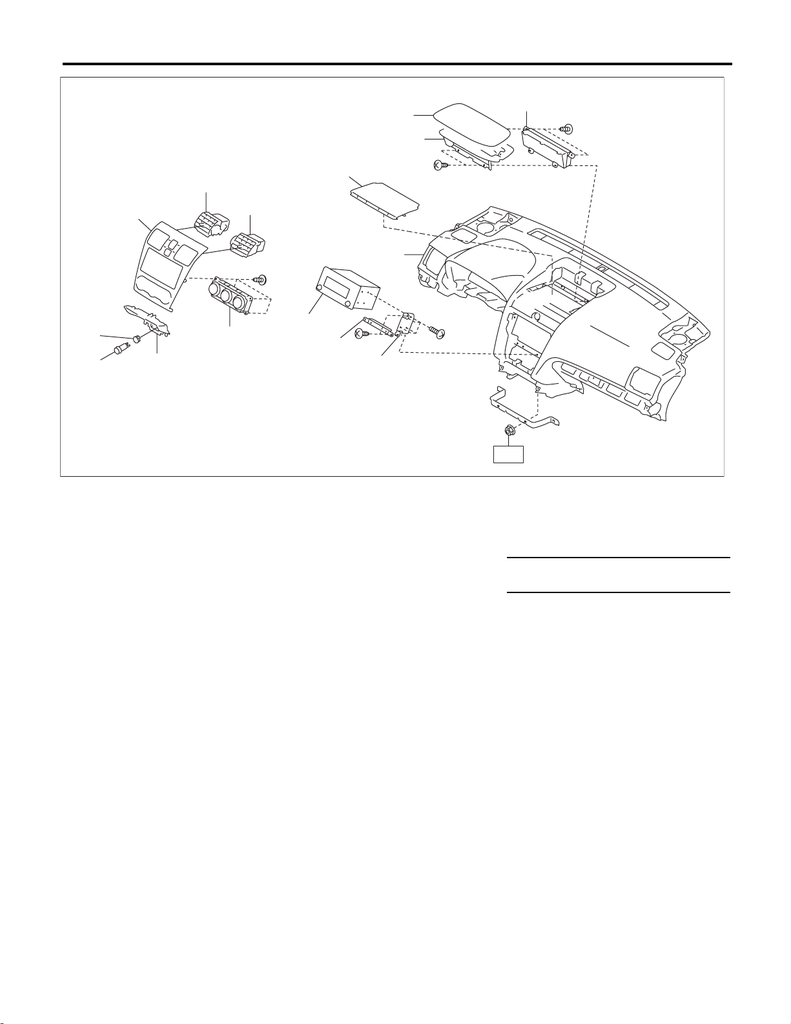

EI-15

General Description

EXTERIOR/INTERIOR TRIM

(1) Grille ASSY - CTR ventilation LH (7) Heater control ASSY (13) Panel - display UPR

(2) Grille ASSY - CTR ventilation RH (8) Audio ASSY/Navigation ASSY (14) Panel - display LWR

(3) Panel center ASSY (9) Bracket - radio (15) Multi-function display ASSY

(4) Cap (10) Bracket - audio

(5) Socket ASSY (11) Cover center UPR Tightening torque: N·m (kgf-m, ft-lb)

(6) Back panel - center pocket (12) Panel COMPL - instrument T: 7 (0.7, 5.2)

EI-04328

(15)

(1)

(2)

(3)

(4)

(5)

(6)

(7)

(8)

(10)

(11)

(12)

(13)

(14)

T

(9)

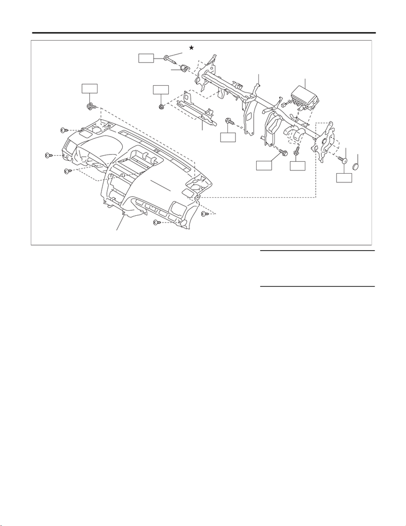

EI-16

General Description

EXTERIOR/INTERIOR TRIM

(1) Panel COMPL - instrument (5) Beam COMPL - steering Tightening torque: N·m (kgf-m, ft-lb)

(2) Cap - bolt (6) TORX

®

bolt (M8 × 57) T1: 7 (0.7, 5.2)

(3) TORX

®

bolt (M8 × 37) (7) Adjuster - clip space T2: 7.5 (0.8, 5.5)

(4) Passenger’s airbag module (8) Knee airbag module T3: 25 (2.5, 18.4)

EI-04344

(1)

T1

(4)

(5)

(7)

(8)

T2

T3

T2

T3

T3

T3

(3)

(6)

(2)

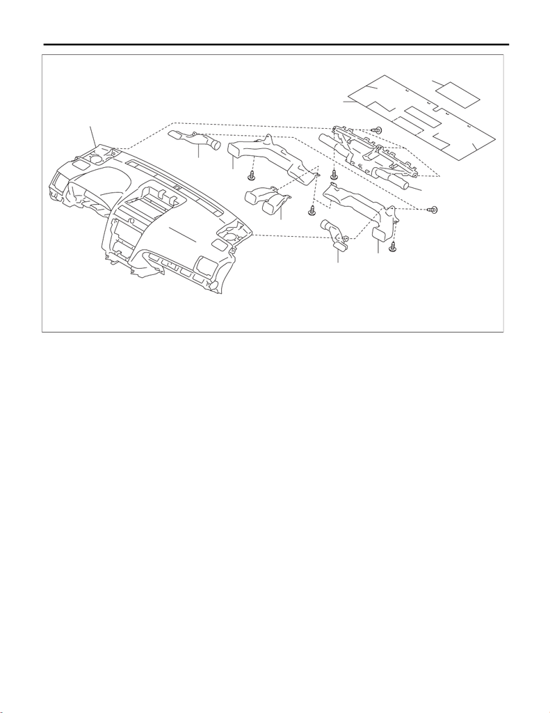

EI-17

General Description

EXTERIOR/INTERIOR TRIM

(1) Panel COMPL - instrument (4) Duct - center vent (7) Nozzle - front defroster

(2) Duct - side defroster LH (5) Duct - side defroster RH (8) Insulator - instrument

(3) Duct - side ventilation LH (6) Duct - side ventilation RH (9) Insulator - airbag

EI-03621

(1)

(3)

(4)

(5)

(6)

(7)

(2)

(8)

(9)

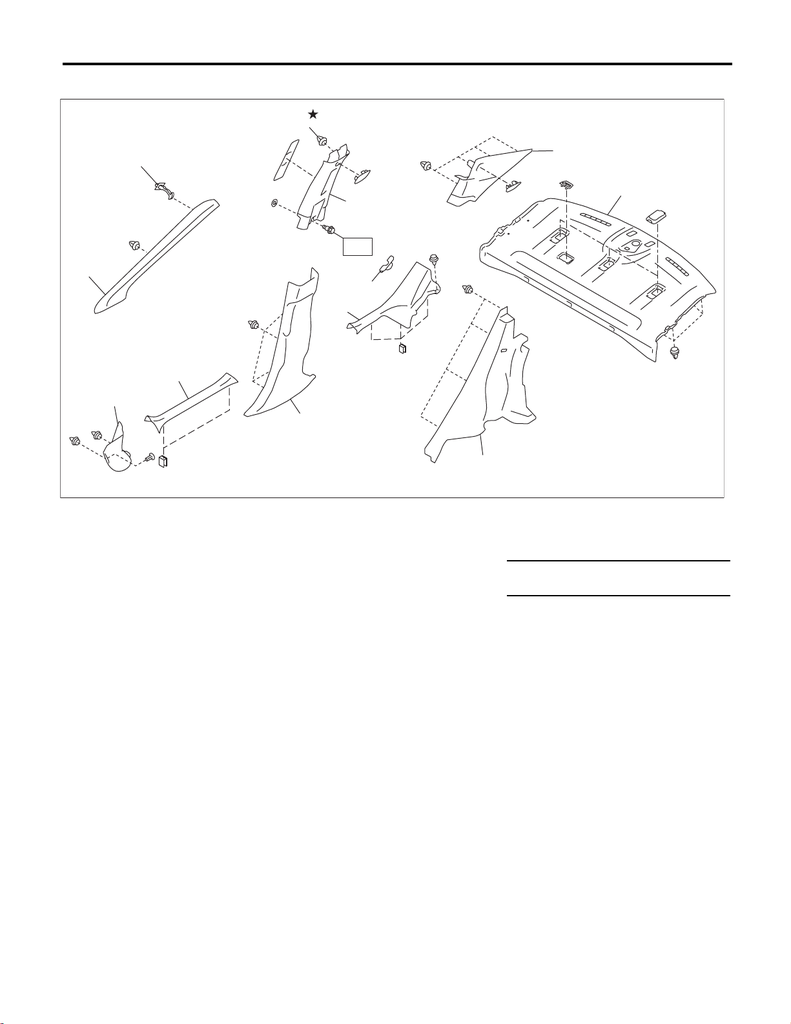

EI-18

General Description

EXTERIOR/INTERIOR TRIM

18.INNER TRIM

(1) Tether clip (6) Trim panel - center pillar UPR (11) Trim panel - rear pillar UPR

(2) Trim panel - front pillar UPR (7) Trim panel - center pillar LWR (12) Trim panel ASSY - rear shelf

(3) Cover side sill - front (8) Cover - catcher

(4) Cover side sill - front INN (9) Cover side sill - rear INN Tightening torque: N·m (kgf-m, ft-lb)

(5) Clip (10) Trim panel - rear pillar LWR T: 7.5 (0.8, 5.5)

EI-04385

(2)

(6)

(3)

(4)

(5)

(7)

(10)

(8)

(9)

T

(12)

(1)

(11)

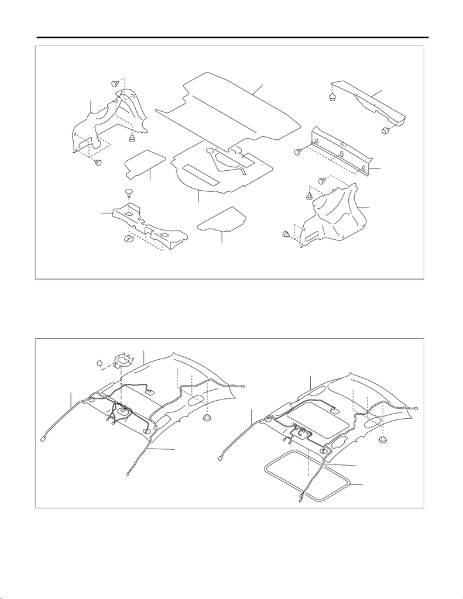

EI-19

General Description

EXTERIOR/INTERIOR TRIM

19.ROOF TRIM

(1) Trim panel - trunk side RH (4) Sub-trunk ASSY (7) Trim panel - trunk side LH

(2) Spacer - rear floor front (5) Spacer - rear floor side LH (8) Trim panel - trunk rear

(3) Spacer - rear floor side RH (6) Mat - trunk (9) Trim panel - trunk lid

(A) Normal roof type (B) Sunroof type

(1) Cord - roof (3) Cord ASSY - antenna feeder (4) Garnish - roof

(2) Trim panel - roof ASSY

EI-03520

(1)

(5)

(2)

(3)

(4)

(6)

(9)

(7)

(8)

EI-04386

(A)

(B)

(2)

(3)

(4)

(3)

(1)

(1)

(2)

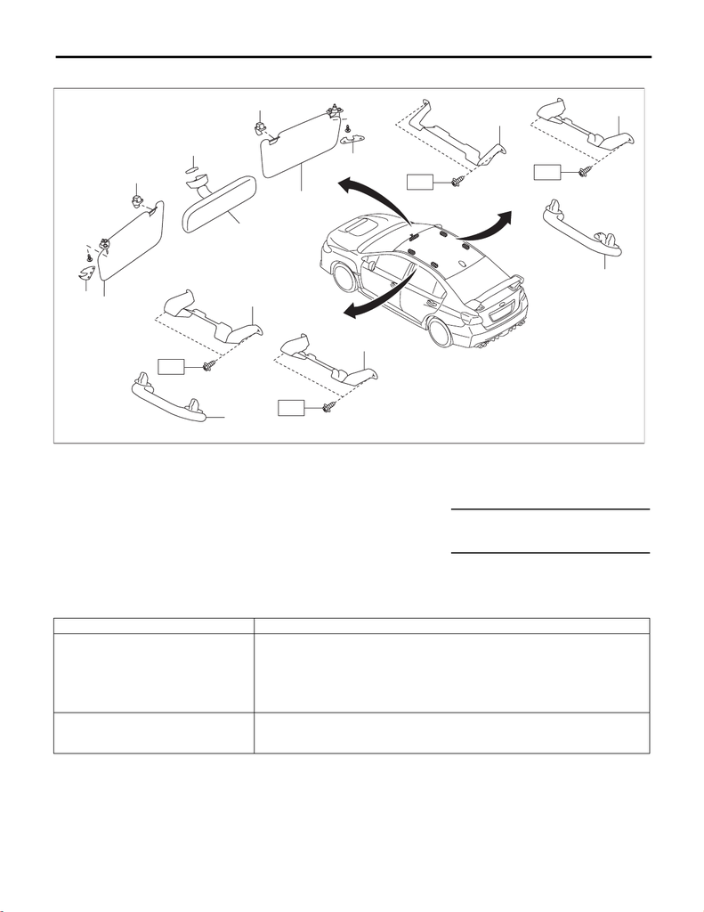

EI-20

General Description

EXTERIOR/INTERIOR TRIM

20.ROOM INNER PARTS

B: PREPARATION TOOL

(1) Base - inner mirror (6) Bracket - assist rail front (model

with sunroof)

(11) Assist rail - rear

(2) Hook - sun visor (7) Bracket - assist rail front (normal

roof)

(3) Mirror ASSY rearview inner (8) Assist rail - front Tightening torque: N·m (kgf-m, ft-lb)

(4) Sun visor ASSY (9) Bracket - assist rail rear (model

with sunroof)

T: 7.5 (0.8, 5.5)

(5) Cap - sun visor (10) Bracket - assist rail rear (normal

roof)

TOOL NAME REMARKS

Clip remover Used for removing trim.

• KTC AP201-10A

• KTC AP201-N

• KTC AP203-10A

• KTC AP20L-10B

Or equivalent.

Clip clamp pliers Used for removal of various clips and clamps.

•KTC CCP-190

Or equivalent.

EI-04387

(1)

(4)

(5)

(4)

(5)

T

T

T

T

(3)

(9)

(6)

(7)

(10)

(11)

(8)

(2)

(2)